# HW2

Erika Bueno

January 25, 2019

#### Problem set 2: Single-species models in continuous time

##### 1) Imagine you are applying your ecology and evolution knowledge to better understand the development of cancer (a burgeoning new field actually (Merlo et al., 2006. Cancer as an evolutionary and ecological process. Nature reviews cancer, 6(12), p.924.). After metastasizing, cancer spread throughout the body, a single cancer cell reached the patient’s colon. The cancer cell now divides and grows at an exponential rate. Spratt et. al (1996) found that colon cancer had an average doubling time of 109 days. Assume a lethal cancer size is on the order of 1x10^12 cells. How long will it take for the colon tumor to reach this lethal size if left untreated?

```r
#knowns: grows exponentially, population doubles at 109 days, lethal size of population is 1x10^12 cells.

#question asks: solve for time at which N= 1x10^12 given the rate of growth
#No= 1
#dN/dT= rN (1-N)- HN
#Nt= Noe^rt
#t= 109 days #time to double
#r =ln(2)/t
# solving for r
timetodouble=109
r= log(2)/109
r
```

```
## [1] 0.006359148
```

```r
#r= 0.006359148

#solving for t
log(1e+12)
```

```
## [1] 27.63102
```

```r
lnNt<-log(1e+12)
lnNt
```

```
## [1] 27.63102
```

```r
lnNo<-log(1)
lnNo
```

```
## [1] 0
```

```r
t<- (lnNt- lnNo)/r
t
```

```
## [1] 4345.082
```

```r
#t= 4345.082 days
years<-t/365
#time to reach 1*10^12 cells is 11.9 years
```

##### 2) Sterile insect release

##### One strategy to combat problematic insect species (like malaria-carrying mosquitoes) is to release sterile males to overwhelm the population. This approach is being used to control Aedes aegypti and Aedes albopictus mosquitoes in the hopes of preventing dengue and yellow fever. The equation below denotes the number of females (F), number of males (M), birth rate (b), and death rate (d). Determine the equilibrium points and the stability of each for the equation. Which equilibrium point tells you the critical threshold for population extinction? How does this relate to the Allee effect?

```r
# dN/dt= b*N/N+M - d

# equilbrium points N*
# N*= dM/b-d
# N*= 0

# stability point
# F= b*N/N+M -d #taking the derivative of F in terms of N
# dF/dN=[b*N/N+M -d]
# = b[dF/dN N/N+M] - 0 #applying the chain rule d/dN=F (G(N)), d goes to zero because its a constant
# = b [(N+M)*1 - N(1+0)/(N+M)^2] #M is a constant because its not in terms of N
# = b[N+M-N/(N+M)^2]=> b[M/(N+M)^2]
# dF/dN|N=dM/b-d => (b-d)^2/bM
```

##### The numerator will always remain postive, stable when (b-d)^2 does equal 0 (b cannot be equal to d) and when bM is less than 0 (which is biologically impossible; birthrate and and number of males cannot equal zero) Therefore, never stable.

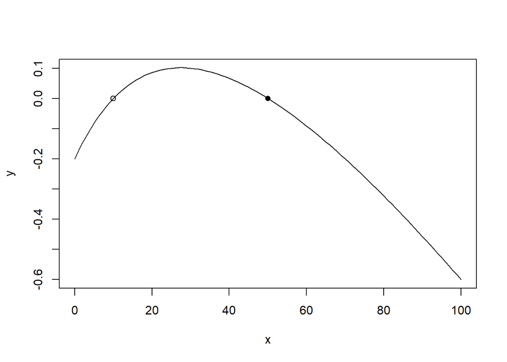

```r
# Equilbrium points:N*=10, N*=50
# Stability points: dF/dN|b*N/(N+M) - d - c*N => [bM/(N+M)^2] - c

# parameters
b=2.4
c=0.02
M=50
d=0.2
#stability<- b*M/((N+M)^2) - c
N1=10
dFdN1 <- b*(M/(N1+M)^2) - c
# print(dFdN1) 0.013 #close to zero
N2= 50
dFdN2<- b*(M/(N2+M)^2) - c
# print(dFdN2) -0.008 #negative value

# Plot of b*N/(N+M) - d - c*N

x<- c(10,50)
y<- c(0,0)
points<-cbind(x,y)

curve(b*x/(x+M) - d - c*x, from=-0, to=100, xlab="x", ylab="y")
points(points, pch=c(1,16))


func<-b*x/(x+M) - d - c*x

newpoints<-as.data.frame(points)

# using ggplot
library(ggplot2)
```

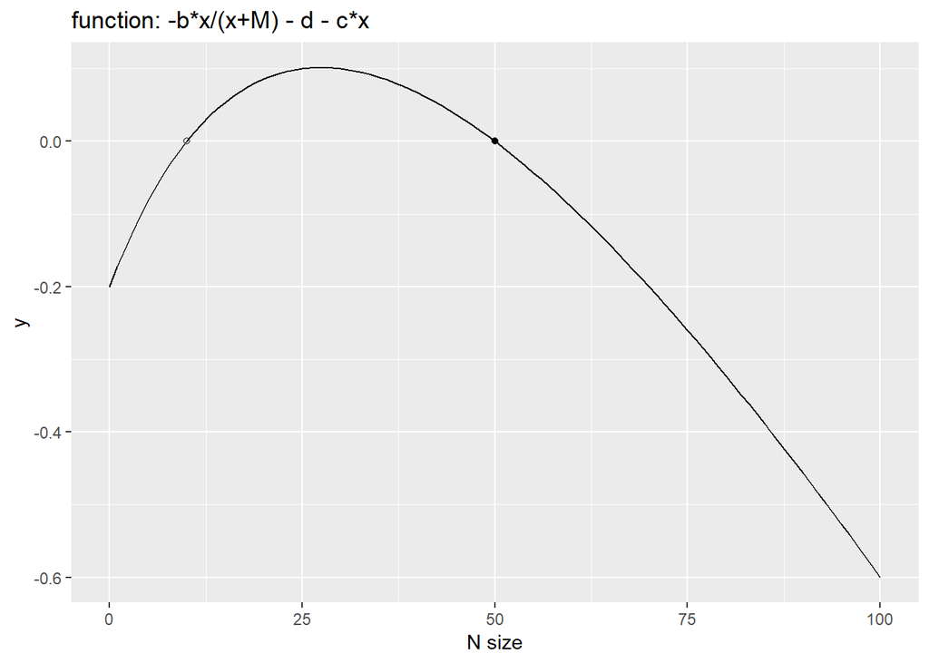

```r
test <- function(x) {2.4 * x/(x+50) - 0.2 - 0.02 * x}
f <- ggplot(data.frame(x = c(-0, 100)), aes(x)) + xlab("N size") + labs(title = "function: -b*x/(x+M) - d - c*x ")
f + stat_function(fun = test) +geom_point(data=newpoints, aes(x=x, y=y),pch=c(1,16))
```

```r
#point N*10 is unstable and will go to extinction while N*50 is stable and will grow
```